# Basic Data Preprocessing

Data pre-processing techniques generally refer to the addition, deletion, or transformation of training set data.

Data preparation can make or break a model's predictive ability; Diﬀerent models have diﬀerent sensitivities to the type of features in the model.

How the features are encoded, called feature engineering, can have a signiﬁcant impact on model performance. Often the most eﬀective encoding of the data is informed by the modeler's understanding of the problem and thus is not derived from any mathematical technique.

## Dataset Description

```python
df.head(5)
```

|  | PassengerId | Survived | Pclass | Name | Sex | Age | SibSp | Parch | Ticket | Fare | Cabin | Embarked |
| --- | --- | --- | --- | --- | --- | --- | --- | --- | --- | --- | --- | --- |
| 0 | 1 | 0 | 3 | Braund, Mr. Owen Harris | male | 22.0 | 1 | 0 | A/5 21171 | 7.2500 | NaN | S |
| 1 | 2 | 1 | 1 | Cumings, Mrs. John Bradley (Florence Briggs Th... | female | 38.0 | 1 | 0 | PC 17599 | 71.2833 | C85 | C |
| 2 | 3 | 1 | 3 | Heikkinen, Miss. Laina | female | 26.0 | 0 | 0 | STON/O2. 3101282 | 7.9250 | NaN | S |
| 3 | 4 | 1 | 1 | Futrelle, Mrs. Jacques Heath (Lily May Peel) | female | 35.0 | 1 | 0 | 113803 | 53.1000 | C123 | S |
| 4 | 5 | 0 | 3 | Allen, Mr. William Henry | male | 35.0 | 0 | 0 | 373450 | 8.0500 | NaN | S |

## Data Transformations for Individual Features

## Centering and Scaling

The most straightforward and common data transformation is to center scale the variables.

To center a feature, the average feature value is subtracted from all the values. Similarly, to scale the data, each value of the variable is divided by its standard deviation.

$$ \hat{x} = \frac{x - \mu_x}{\sigma} $$

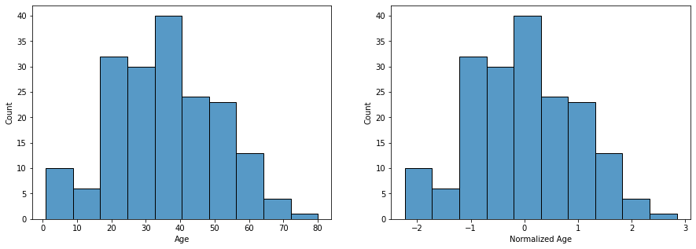

```python
figure
```

Another common scaler is the min-max scaler, where the minimum feature value is substracted from all the values and then divided by the diﬀerence between the minimum and maximum feature value.

$$ \hat{x} = \frac{x - min(x)}{max(x) - min(x)} $$

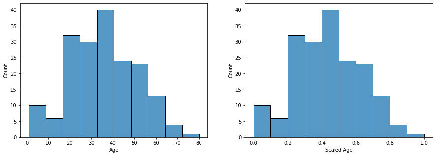

```python
figure
```

## Resolve Skewness

Another common reason for transformations is to remove distributional skewness. An un-skewed distribution is one that is roughly symmetric. This means that the probability of falling on either side of the distribution's mean is roughly equal.

The skewness is deﬁned as the third normalized moment

$$ \mathbb{E}\left[{\left( \frac{x - \mu_x}{\sigma_x} \right)^3}\right] $$

A general rule of thumb to consider is that if the metric is greater or lower than +2 or -2 the data have significant skewness.

Replacing the data with the log, square root, or inverse may help to remove the skew.

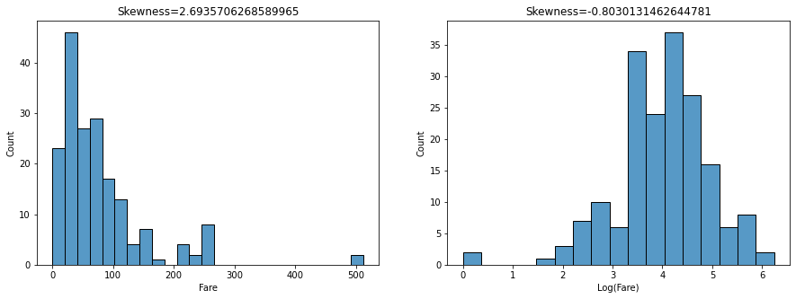

```python
figure
```

## Data Transformation for Multiple Features

## Resolving Outliers

We will generally deﬁne outliers as samples that are exceptionally far from the mainstream of the data.

One data transformation that can minimize the problem is the *spatial sign*. This procedure projects the feature values onto a multidimensional sphere.

$$ \boldsymbol{x}_{i}^{*} = \frac{\boldsymbol{x}_{i}}{|| \boldsymbol{x}_{i} ||} $$

Since the denominator is intended to measure the squared distance to the center of the feature's distribution, it is important to center and scale the variable data prior to using this transformation.

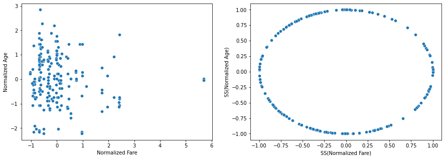

```python
figure
```

## Data Reduction and Features Extraction

Data reduction techniques are another class of feature transformations. These methods reduce the data by generating a smaller set of features that seek to capture a majority of the information in the original variables.

For most data reduction techniques, the new features are functions of the original chaacteristics; therefore, all the original features are still needed to create the surrogate variables. This class of methods is often called "signal extraction" or "feature extraction" techniques.

Principal Component Analysis (PCA) is a commonly used data reduction technique. This method seeks to ﬁnd linear combinations of the features, known as principal components (PCs), which capture the most possible variance.

## Principal Component Analysis

Consider an $N \times d$ data matrix, $X$, with column-wise zero empirical mean (the sample mean of each column has been shifted to zero).

$$ X = \begin{bmatrix} \text{---} & \boldsymbol{x}_{(1)} & \text{---} \\ \text{---} & \boldsymbol{x}_{(2)} & \text{---} \\ & \vdots & \\ \text{---} & \boldsymbol{x}_{(N)} & \text{---} \\ \end{bmatrix} $$

The transformation is defined by a set of size $k$ of $d$-dimensional vectors of weights $\boldsymbol{w}_{(j)} = (w_1, w_2, \cdots, w_d)_{(j)}$ that map each row vector $\boldsymbol{x}_{(i)}$ of $X$ to a new vector of principal component scores $\boldsymbol{t}_{(i)} = (t_1, t_2, \cdots, t_k)_{(i)}$, given by:

$$ t_{j(i)} = \boldsymbol{x}_{(i)} \cdot w_{(j)} \:\:\: \text{for }i=1,\cdots,N \:\:\: j=1,\cdots,k $$

in such a way that the individual variables $t_1, t_2, \cdots, t_k$ of $\boldsymbol{t}_{(i)}$ considered over the data set successively inherit the maximum possible variance from $X$, with each coefficient vector $\boldsymbol{w}_{(j)}$ constrained to be a unit vector.

### First Component

In order to maximize variance, the first weight vector $\boldsymbol{w}_{(1)}$ thus has to satisfy

$$ \boldsymbol{w}_{(1)} = arg\max_{||\boldsymbol{w}|| = 1} \left\{ \sum_{i=1}^N (t_1)_{(i)}^2 \right\} = arg\max_{||\boldsymbol{w}|| = 1} \left\{ \sum_{i=1}^N (\boldsymbol{x}_{(i)} \cdot \boldsymbol{w})^2 \right\} = arg\max_{||\boldsymbol{w}|| = 1} \left\{ || X \boldsymbol{w} ||^2 \right\} \\ = arg\max_{||\boldsymbol{w}|| = 1} \left\{ \boldsymbol{w}^T X^T X \boldsymbol{w} \right\} $$

Since $\boldsymbol{w}_{(1)}$ has been defined to be a unit vector, it equivalently also satisfies

$$ \boldsymbol{w}_{(1)} = argmax \left\{ \frac{\boldsymbol{w}^T X^T X \boldsymbol{w}}{\boldsymbol{w}^T\boldsymbol{w}} \right\} $$

The quantity to be maximised can be recognised as a *Rayleigh quotient*. A standard result for a positive semidefinite matrix such as $X^T X$ is that the quotient's maximum possible value is the largest eigenvalue of the matrix, which occurs when $\boldsymbol{w}$ is the corresponding eigenvector.

### Further Components

The $j$-th component can be found by subtracting the first $j-1$ principal components from $X$:

$$ \hat{X}_j = X - \sum_{s=1}^{j-1} X \boldsymbol{w}_{(s)} \boldsymbol{w}_{(s)}^T $$

and then finding the weight vector which extracts the maximum variance from this new data matrix

$$ \boldsymbol{w}_{(j)} = arg\max_{||\boldsymbol{w}|| = 1} \left\{ || \hat{X}_j \boldsymbol{w} ||^2 \right\} = argmax \left\{ \frac{\boldsymbol{w}^T \hat{X}_j^T \hat{X}_j \boldsymbol{w}}{\boldsymbol{w}^T\boldsymbol{w}} \right\} $$

## Dealing with Missing Values

### Missing Data

In many cases, some features have no values for a given sample. It is important to understand why the values are missing. First and foremost, it is important to know if the pattern of missing data is related to the outcome. This is called *informative missingness* since the missing data pattern is instructional on its own.

Suppose the drug was extremely ineﬀective or had signiﬁcant side eﬀects. The patient may be likely to miss doctor visits or to drop out of the study. In this case, there clearly is a relationship between the probability of missing values and the treatment.

Customer ratings can often have informative missingness; people are more compelled to rate products when they have strong opinions (good or bad).

### Censored Data

Missing data should not be confused with censored data where the exact value is missing but something is known about its value.

Censored data can also be common when using laboratory measurements. Some assays cannot measure below their limit of detection. In such cases, we know that the value is smaller than the limit but was not precisely measured.

**Are censored data treated diﬀerently than missing data?** When building traditional statistical models focused on interpretation or inference, the censoring is usually taken into account in a formal manner by making assumptions about the censoring mechanism. For predictive models, it is more common to treat these data as simple missing data or use the censored value as the observed value.

For large data sets, removal of samples based on missing values is not a problem, assuming that the missingness is not informative. In smaller data sets, there is a price in removing samples; some of the alternative approaches described below may be more appropriate.

- First, a few predictive models, can speciﬁcally account for missing data.
- Alternatively, missing data can be imputed. In this case, we can use information in the training set features to, in essence, estimate the values of other features. This amounts to a predictive model within a predictive model.

The most relevant scheme for filling missing values is to use the training set to built an imputation model for each feature in the data set. Prior to model training or the prediction of new samples, missing values are ﬁlled in using imputation.

If the number of predictors aﬀected by missing values is small, an EDA of the relationships between the predictors is a good idea. Some examples are:

- Use PCA to determine if there are strong relationships. If a variable with missing values is highly correlated to another feature, a focused model could be eﬀective.
- Replace missing values with a proper feature statistic value, for example, with the mean, the medain or the mode.

## Removing Features

There are potential advantages to removing features prior to modeling.

1. Fewer features means decreased computational time and complexity.
2. If two features are highly correlated, this implies that they are measuring the same underlying information.
3. Some models can be crippled by features with degenerate distributions. In these cases, there can be a signiﬁcant improvement in model performance and/or stability without the problematic variables.

**Consider the problem of stop-words in NLP applications.**

An heuristic approach to dealing with this issue isto remove the minimum number of features to ensure that all pairwise correlations are below a certain threshold. While this method only identify collinearities in two dimensions, it can have a signiﬁcantly positive eﬀect on the performance of some models.

**Algorithm**

1. Calculate the correlation matrix of the predictors.
2. Determine the two features associated with the largest absolute pairwise correlation over a deﬁned threshold (call them features A and B).
3. Determine the average correlation between A and the other variables. Do the same for feature B.
4. If A has a larger average correlation, remove it; otherwise, remove feature B.
5. Repeat Steps 2-4 until no absolute correlations are above the threshold.

## Adding Features

## Encoding Features

There are usually several diﬀerent methods for encoding features. For example, consider a feature in a dataset for predicting the number of graduated students, which is a date. This date can be represented in many ways:

- The number of days since a reference date.
- Isolating the month, year, and day of the week as separate features.
- The numeric day of the year.

The "correct" feature engineering depends on several factors.

## One-Hot Encoding

When a predictor is categorical, such as gender or race, it is common to decompose the predictor into a set of more speciﬁc variables. This transformation is named *one-hot encoding*. For example, a feature representing the nationality of a person would be represented as follow:

| Nationality | Mexican | American | German | French | Italian |
| --- | --- | --- | --- | --- | --- |
| **Mexican** | 1 | 0 | 0 | 0 | 0 |
| **American** | 0 | 1 | 0 | 0 | 0 |
| **German** | 0 | 0 | 1 | 0 | 0 |
| **French** | 0 | 0 | 0 | 1 | 0 |
| **Italian** | 0 | 0 | 0 | 0 | 1 |

## $\mathcal{Z}$ Transformation

Sometimes the space formed by the features is complex for some models to perform a task, then, by adding a nonlinear transformation depending on current features could be useful. An common non linear transformation is

$$ \phi_2(\boldsymbol{x})=(1,x_1,x_2,x_1^2,x_1 x_2, x_2^2) $$

where $\boldsymbol{x}=(x_1, x_2)$ represents a row in a dataset, and $x_1$, $x_2$ are the example features. One may further extend $\phi_2$ to a feature transform $\phi_Q$ for $Q$-degree curves.